# L05 Tibbles

Data Science 1 with R (STAT 301-1)

Author

Ryan Nguyen

## Overview

The goal of this lab is to better understand the basic data structure called a “tibble,” which is used throughout the `tidyverse` instead of R’s traditional `data.frame`. Tibbles are data frames, but they tweak some of R’s older behaviors to make life a little easier by avoiding unintentional mistakes/errors. The `tibble` package provides the framework for these opinionated data frames which make working with data in the tidyverse possible – [`tibble` package home page](http://tibble.tidyverse.org/index.html).

## Load Packages

```r
# Loading package(s)
library(tidyverse, quietly = T)
library(tibble)
library(nycflights13)
```

## Datasets

This lab utilizes the `mtcars` and `flights` datasets contained in the packages `datasets` (automatically loaded with base R) and `nycflights13`, respectively. For one of the problems, you may opt to use one of our other familiar datasets, `diamonds` or `mpg`, which are contained in `ggplot2`.

## Exercises

### Exercise 1

Please read the vignette for the `tibble` package.

```r
# Access vignette
vignette("tibble")
```

> COMPLETED

### Exercise 2

Demonstrate how to manually input the data table below into R using each of these functions:

- `tibble()`
- `tribble()`

| price | store | ounces |
| --- | --- | --- |
| 3.99 | target | 128 |
| 3.75 | walmart | 128 |
| 3.00 | amazon | 128 |

```r
tibble(
  `price` = c(3.99, 3.75, 3.00),
  `store` = c("target", "walmart", "amazon"),
  `ounces` = rep(128, 3)
)
```

```
# A tibble: 3 × 3
  price store   ounces
  <dbl> <chr>    <dbl>
1  3.99 target     128
2  3.75 walmart    128
3  3    amazon     128
```

```r
tribble(
  ~price, ~store, ~ounces,
  #-----|-------|--------
  3.99, "target", 128,
  3.75, "walmart", 128,
  3.00, "amazon", 128
)
```

```
# A tibble: 3 × 3
  price store   ounces
  <dbl> <chr>    <dbl>
1  3.99 target     128
2  3.75 walmart    128
3  3    amazon     128
```

### Exercise 3

How can you tell if an object is a tibble? Consider including an example or two. (Hint: try printing `mtcars`, which is a regular data frame).

```r
data.frame(mtcars)
```

```
                     mpg cyl  disp  hp drat    wt  qsec vs am gear carb
Mazda RX4           21.0   6 160.0 110 3.90 2.620 16.46  0  1    4    4
Mazda RX4 Wag       21.0   6 160.0 110 3.90 2.875 17.02  0  1    4    4
Datsun 710          22.8   4 108.0  93 3.85 2.320 18.61  1  1    4    1
Hornet 4 Drive      21.4   6 258.0 110 3.08 3.215 19.44  1  0    3    1
Hornet Sportabout   18.7   8 360.0 175 3.15 3.440 17.02  0  0    3    2
Valiant             18.1   6 225.0 105 2.76 3.460 20.22  1  0    3    1
Duster 360          14.3   8 360.0 245 3.21 3.570 15.84  0  0    3    4
Merc 240D           24.4   4 146.7  62 3.69 3.190 20.00  1  0    4    2
Merc 230            22.8   4 140.8  95 3.92 3.150 22.90  1  0    4    2
Merc 280            19.2   6 167.6 123 3.92 3.440 18.30  1  0    4    4
Merc 280C           17.8   6 167.6 123 3.92 3.440 18.90  1  0    4    4
Merc 450SE          16.4   8 275.8 180 3.07 4.070 17.40  0  0    3    3
Merc 450SL          17.3   8 275.8 180 3.07 3.730 17.60  0  0    3    3
Merc 450SLC         15.2   8 275.8 180 3.07 3.780 18.00  0  0    3    3
Cadillac Fleetwood  10.4   8 472.0 205 2.93 5.250 17.98  0  0    3    4
Lincoln Continental 10.4   8 460.0 215 3.00 5.424 17.82  0  0    3    4
Chrysler Imperial   14.7   8 440.0 230 3.23 5.345 17.42  0  0    3    4
Fiat 128            32.4   4  78.7  66 4.08 2.200 19.47  1  1    4    1
Honda Civic         30.4   4  75.7  52 4.93 1.615 18.52  1  1    4    2
Toyota Corolla      33.9   4  71.1  65 4.22 1.835 19.90  1  1    4    1
Toyota Corona       21.5   4 120.1  97 3.70 2.465 20.01  1  0    3    1
Dodge Challenger    15.5   8 318.0 150 2.76 3.520 16.87  0  0    3    2
AMC Javelin         15.2   8 304.0 150 3.15 3.435 17.30  0  0    3    2
Camaro Z28          13.3   8 350.0 245 3.73 3.840 15.41  0  0    3    4
Pontiac Firebird    19.2   8 400.0 175 3.08 3.845 17.05  0  0    3    2
Fiat X1-9           27.3   4  79.0  66 4.08 1.935 18.90  1  1    4    1
Porsche 914-2       26.0   4 120.3  91 4.43 2.140 16.70  0  1    5    2
Lotus Europa        30.4   4  95.1 113 3.77 1.513 16.90  1  1    5    2
Ford Pantera L      15.8   8 351.0 264 4.22 3.170 14.50  0  1    5    4
Ferrari Dino        19.7   6 145.0 175 3.62 2.770 15.50  0  1    5    6
Maserati Bora       15.0   8 301.0 335 3.54 3.570 14.60  0  1    5    8
Volvo 142E          21.4   4 121.0 109 4.11 2.780 18.60  1  1    4    2
```

```r
as_tibble(mtcars)
```

```
# A tibble: 32 × 11
     mpg   cyl  disp    hp  drat    wt  qsec    vs    am  gear  carb
   <dbl> <dbl> <dbl> <dbl> <dbl> <dbl> <dbl> <dbl> <dbl> <dbl> <dbl>
 1  21       6  160    110  3.9   2.62  16.5     0     1     4     4
 2  21       6  160    110  3.9   2.88  17.0     0     1     4     4
 3  22.8     4  108     93  3.85  2.32  18.6     1     1     4     1
 4  21.4     6  258    110  3.08  3.22  19.4     1     0     3     1
 5  18.7     8  360    175  3.15  3.44  17.0     0     0     3     2
 6  18.1     6  225    105  2.76  3.46  20.2     1     0     3     1
 7  14.3     8  360    245  3.21  3.57  15.8     0     0     3     4
 8  24.4     4  147.    62  3.69  3.19  20       1     0     4     2
 9  22.8     4  141.    95  3.92  3.15  22.9     1     0     4     2
10  19.2     6  168.   123  3.92  3.44  18.3     1     0     4     4
# … with 22 more rows
```

### Exercise 4

Turn `mtcars` into a tibble and ask R to print only the first 4 observations/rows. Consider using a `slice_*()` function.

```r
as_tibble(mtcars) %>%
  slice_head(n = 4)
```

```
# A tibble: 4 × 11
    mpg   cyl  disp    hp  drat    wt  qsec    vs    am  gear  carb
  <dbl> <dbl> <dbl> <dbl> <dbl> <dbl> <dbl> <dbl> <dbl> <dbl> <dbl>
1  21       6   160   110  3.9   2.62  16.5     0     1     4     4
2  21       6   160   110  3.9   2.88  17.0     0     1     4     4
3  22.8     4   108    93  3.85  2.32  18.6     1     1     4     1
4  21.4     6   258   110  3.08  3.22  19.4     1     0     3     1
```

### Exercise 5

Run the following operations on `df` as a data frame. Then turn `df` into a tibble and run the operations again. What changes? Why might the default data frame behaviors cause problems or frustration?

```r
df <- data.frame(abc = 1, xyz = "a")
df$x
```

```
[1] "a"
```

```r
df[, "xyz"]
```

```
[1] "a"
```

```r
df[, c("abc", "xyz")]
```

```
  abc xyz
1   1   a
```

```r
df2 <- tibble(abc = 1, xyz = "a")
df2$x
```

[output not shown]

```r
df2[, "xyz"]
```

```
# A tibble: 1 × 1
  xyz
  <chr>
1 a
```

```r
df2[, c("abc", "xyz")]
```

```
# A tibble: 1 × 2
    abc xyz
  <dbl> <chr>
1     1 a
```

**ANSWER:** When running the $ operation on the data frame, it is still able to return “a” because the data frame is running partial matching. On the other hand, when running the operation on the tibble, it returns a warning and null since the column does not exist; tibbles never do partial matching. This could cause a problems in the data frame because if you have a typo or are searching for a really specific variable, it will return a partial match, and not warn you if you made a mistake. It could potentially return data that you were not even looking for. For the second operation, when subsetting, tibbles always return another tibble, wheras the data frame returned just a vector. Lastly, when returning the entire data frame/tibble, they appear to be similar, besides the labels at the top.

### Exercise 6

If you have the name of a variable stored as an object, for example `var <- "mpg"`, how can you extract the specified variable from a tibble? Write code to demonstrate.

```r
as_tibble(mpg)
```

```
# A tibble: 234 × 11
   manufacturer model      displ  year   cyl trans drv     cty   hwy fl    class
   <chr>        <chr>      <dbl> <int> <int> <chr> <chr> <int> <int> <chr> <chr>
 1 audi         a4           1.8  1999     4 auto… f        18    29 p     comp…
 2 audi         a4           1.8  1999     4 manu… f        21    29 p     comp…
 3 audi         a4           2    2008     4 manu… f        20    31 p     comp…
 4 audi         a4           2    2008     4 auto… f        21    30 p     comp…
 5 audi         a4           2.8  1999     6 auto… f        16    26 p     comp…
 6 audi         a4           2.8  1999     6 manu… f        18    26 p     comp…
 7 audi         a4           3.1  2008     6 auto… f        18    27 p     comp…
 8 audi         a4 quattro   1.8  1999     4 manu… 4        18    26 p     comp…
 9 audi         a4 quattro   1.8  1999     4 auto… 4        16    25 p     comp…
10 audi         a4 quattro   2    2008     4 manu… 4        20    28 p     comp…
# … with 224 more rows
```

```r
var <- "displ"
mpg %>%
  select(var)
```

```
# A tibble: 234 × 1
   displ
   <dbl>
 1   1.8
 2   1.8
 3   2
 4   2
 5   2.8
 6   2.8
 7   3.1
 8   1.8
 9   1.8
10   2
# … with 224 more rows
```

### Exercise 7

How is subsetting via `[[ ]]` different from using `select()` when extracting columns of a tibble? (Hint: Investigate using one of our familiar datasets — `flights`, `diamonds`, or `mpg`.)

```r
mpg[["cyl"]]
```

```
  [1] 4 4 4 4 6 6 6 4 4 4 4 6 6 6 6 6 6 8 8 8 8 8 8 8 8 8 8 8 8 8 8 8 4 4 6 6 6
 [38] 4 6 6 6 6 6 6 6 6 6 6 6 6 6 6 8 8 8 8 8 6 8 8 8 8 8 8 8 8 8 8 8 8 8 8 8 8
 [75] 8 8 8 6 6 6 6 8 8 6 6 8 8 8 8 8 6 6 6 6 8 8 8 8 8 4 4 4 4 4 4 4 4 4 4 4 4
[112] 4 6 6 6 4 4 4 4 6 6 6 6 6 6 8 8 8 8 8 8 8 8 8 8 8 8 6 6 8 8 4 4 4 4 6 6 6
[149] 6 6 6 6 6 8 6 6 6 6 8 4 4 4 4 4 4 4 4 4 4 4 4 4 4 4 4 6 6 6 8 4 4 4 4 6 6
[186] 6 4 4 4 4 6 6 6 4 4 4 4 4 8 8 4 4 4 6 6 6 6 4 4 4 4 6 4 4 4 4 4 5 5 6 6 4
[223] 4 4 4 5 5 4 4 4 4 6 6 6
```

```r
mpg %>%
  select(cyl)
```

```
# A tibble: 234 × 1
     cyl
   <int>
 1     4
 2     4
 3     4
 4     4
 5     6
 6     6
 7     6
 8     4
 9     4
10     4
# … with 224 more rows
```

**ANSWER:** When subsetting via `[[ ]]`, it returns all of the vectors within the column. On the other hand, when extracting columns via tibble and `select()`, it returns a tibble with the one column that you extracted.

### Exercise 8

Practice referring to non-syntactic names in the following data frame by:

```r
# toy dataset
annoying <- tibble(
  `1` = 1:10,
  `2` = `1` * 2 + rnorm(length(`1`))
)

print(annoying)
```

```
# A tibble: 10 × 2
     `1`   `2`
   <int> <dbl>
 1     1  1.76
 2     2  3.69
 3     3  5.57
 4     4  9.10
 5     5  9.30
 6     6 12.4
 7     7 11.0
 8     8 15.4
 9     9 15.9
10    10 19.7
```

1. Extracting the variable called 1.
2. Plotting a scatterplot of 1 vs 2.
3. Creating a new column called 3 which is 2 divided by 1.
4. Renaming the columns to one, two and three.

```r
annoying$"1"
```

```
 [1]  1  2  3  4  5  6  7  8  9 10
```

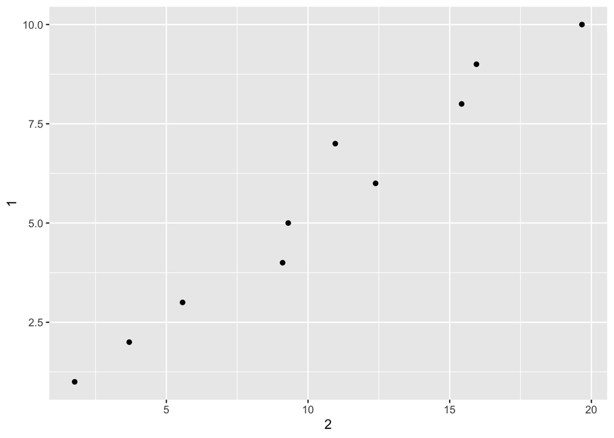

```r
annoying %>%
  ggplot(aes(x = .data[["2"]], y = .data[["1"]])) +
  geom_point()
```

```r
annoying2 <- annoying %>%
  mutate("3" = .data[["2"]] / .data [["1"]])

annoying2
```

```
# A tibble: 10 × 3
     `1`   `2`   `3`
   <int> <dbl> <dbl>
 1     1  1.76  1.76
 2     2  3.69  1.85
 3     3  5.57  1.86
 4     4  9.10  2.28
 5     5  9.30  1.86
 6     6 12.4   2.06
 7     7 11.0   1.57
 8     8 15.4   1.93
 9     9 15.9   1.77
10    10 19.7   1.97
```

```r
rename(annoying2,
       "one" = "1",
       "two" = "2",
       "three" = "3")
```

```
# A tibble: 10 × 3
     one   two three
   <int> <dbl> <dbl>
 1     1  1.76  1.76
 2     2  3.69  1.85
 3     3  5.57  1.86
 4     4  9.10  2.28
 5     5  9.30  1.86
 6     6 12.4   2.06
 7     7 11.0   1.57
 8     8 15.4   1.93
 9     9 15.9   1.77
10    10 19.7   1.97
```

### Exercise 9

What does `tibble::enframe()` do? When might you use it? (Hint: A named vector is one where each value has a specified name – examples in code below.)

```r
# example of a named vector
named_vector <- c("I" = 3.14, "love" = 2.72, "stats!" = 1.61)
named_vector
```

```
     I   love stats!
  3.14   2.72   1.61
```

```r
enframe(named_vector)
```

```
# A tibble: 3 × 2
  name   value
  <chr>  <dbl>
1 I       3.14
2 love    2.72
3 stats!  1.61
```

```r
# Consider how enframe() would be helpful in the following example:

# random sample of 1000 from a normal distribution
foo <- rnorm(n = 1000, mean = 100, sd = 15)
summary(foo)
```

```
   Min. 1st Qu.  Median    Mean 3rd Qu.    Max.
  54.03   89.21  100.18  100.20  110.28  144.78
```

```r
foo
```

```
   [1]  79.42380 120.56471  65.29368  98.68288 111.04228 101.34886 116.89149
   [8]  92.82799 115.15160  88.49641  79.84014 117.37984  95.40651  80.15812
  [15]  80.08739 104.46195 109.50409 101.60596 118.49087  85.29194  92.51504
  [22] 118.61222 119.04451 100.48905 121.46838  99.14375 102.06355  98.40625
  [29] 108.95931 109.91194  89.91988  97.21934  83.32788 101.08531 106.84961
  [36] 110.22038  93.27910  77.08878  81.78178 109.88326  80.23658  93.66115
  [43]  93.70951 109.89809  98.42491 128.44024  80.24748 118.44020  92.30424
  [50] 118.18546 110.46951 114.61129 108.70200  89.38523 105.18345  90.75208
  [57]  77.15932  91.00970  95.35553 108.77095  81.50613 115.39453  91.61535
  [64] 108.46772  74.80855 106.41697 123.26846  88.95689  79.66911 102.82257
  [71]  82.43045  88.73298 107.41010 123.00766 123.18605  85.96609  98.14340
  [78]  86.29002  86.74470  89.79310  63.02106 114.27057  98.06451 104.97527
  [85] 109.00734  89.60582  62.19938 122.34862  83.84230 114.24949 102.46661
  [92]  85.42788 103.53305 111.29206  67.88907  93.06908 131.41909  95.59918
  [99]  83.48566 100.41068  93.16306  81.85185 100.03481  87.97618  97.91211
```

[output cut: 128 more lines]

```r
enframe(foo)
```

```
# A tibble: 1,000 × 2
    name value
   <int> <dbl>
 1     1  79.4
 2     2 121.
 3     3  65.3
 4     4  98.7
 5     5 111.
 6     6 101.
 7     7 117.
 8     8  92.8
 9     9 115.
10    10  88.5
# … with 990 more rows
```

**ANSWER:** `enframe()` converts vectors or lists to one or two column data frames/tibbles with the vectors split into columns. One might use it when there is a large list or amount of vectors, and you want to nicely split it up into organized, tidy columns in a tibble. It could be useful in a named vector where each value has a specified name, because you can see the specified name clearly in columns, as well as mutate the columns if needed.

### Exercise 10

Apply `tibble::glimpse()` to the `flights` dataset. Then apply `print()` to `flights`. When/why might `glimpse()` be more useful than `print()`?

```r
tibble::glimpse(flights)
```

```
Rows: 336,776
Columns: 19
$ year           <int> 2013, 2013, 2013, 2013, 2013, 2013, 2013, 2013, 2013, 2…
$ month          <int> 1, 1, 1, 1, 1, 1, 1, 1, 1, 1, 1, 1, 1, 1, 1, 1, 1, 1, 1…
$ day            <int> 1, 1, 1, 1, 1, 1, 1, 1, 1, 1, 1, 1, 1, 1, 1, 1, 1, 1, 1…
$ dep_time       <int> 517, 533, 542, 544, 554, 554, 555, 557, 557, 558, 558, …
$ sched_dep_time <int> 515, 529, 540, 545, 600, 558, 600, 600, 600, 600, 600, …
$ dep_delay      <dbl> 2, 4, 2, -1, -6, -4, -5, -3, -3, -2, -2, -2, -2, -2, -1…
$ arr_time       <int> 830, 850, 923, 1004, 812, 740, 913, 709, 838, 753, 849,…
$ sched_arr_time <int> 819, 830, 850, 1022, 837, 728, 854, 723, 846, 745, 851,…
$ arr_delay      <dbl> 11, 20, 33, -18, -25, 12, 19, -14, -8, 8, -2, -3, 7, -1…
$ carrier        <chr> "UA", "UA", "AA", "B6", "DL", "UA", "B6", "EV", "B6", "…
$ flight         <int> 1545, 1714, 1141, 725, 461, 1696, 507, 5708, 79, 301, 4…
$ tailnum        <chr> "N14228", "N24211", "N619AA", "N804JB", "N668DN", "N394…
$ origin         <chr> "EWR", "LGA", "JFK", "JFK", "LGA", "EWR", "EWR", "LGA",…
$ dest           <chr> "IAH", "IAH", "MIA", "BQN", "ATL", "ORD", "FLL", "IAD",…
$ air_time       <dbl> 227, 227, 160, 183, 116, 150, 158, 53, 140, 138, 149, 1…
$ distance       <dbl> 1400, 1416, 1089, 1576, 762, 719, 1065, 229, 944, 733, …
$ hour           <dbl> 5, 5, 5, 5, 6, 5, 6, 6, 6, 6, 6, 6, 6, 6, 6, 5, 6, 6, 6…
$ minute         <dbl> 15, 29, 40, 45, 0, 58, 0, 0, 0, 0, 0, 0, 0, 0, 0, 59, 0…
$ time_hour      <dttm> 2013-01-01 05:00:00, 2013-01-01 05:00:00, 2013-01-01 0…
```

```r
print(flights)
```

```
# A tibble: 336,776 × 19
    year month   day dep_time sched_de…¹ dep_d…² arr_t…³ sched…⁴ arr_d…⁵ carrier
   <int> <int> <int>    <int>      <int>   <dbl>   <int>   <int>   <dbl> <chr>
 1  2013     1     1      517        515       2     830     819      11 UA
 2  2013     1     1      533        529       4     850     830      20 UA
 3  2013     1     1      542        540       2     923     850      33 AA
 4  2013     1     1      544        545      -1    1004    1022     -18 B6
 5  2013     1     1      554        600      -6     812     837     -25 DL
 6  2013     1     1      554        558      -4     740     728      12 UA
 7  2013     1     1      555        600      -5     913     854      19 B6
 8  2013     1     1      557        600      -3     709     723     -14 EV
 9  2013     1     1      557        600      -3     838     846      -8 B6
10  2013     1     1      558        600      -2     753     745       8 AA
# … with 336,766 more rows, 9 more variables: flight <int>, tailnum <chr>,
#   origin <chr>, dest <chr>, air_time <dbl>, distance <dbl>, hour <dbl>,
#   minute <dbl>, time_hour <dttm>, and abbreviated variable names
#   ¹sched_dep_time, ²dep_delay, ³arr_time, ⁴sched_arr_time, ⁵arr_delay
```

**ANSWER:** `tibble::glimpse` might be more helpful than `print()` when you want to see all of the variables listed out on the left side, especially when you have a large number of columns or large data sets. It gives you a total view of the data set.